# C7 Week 4 GLMs

JAGV

2024-12-13

# Generalized Linear Models

GLMs (Generalized Linear Models) were a great advance in statistical modeling. Even though linear models are the most useful applied statistical technique, they have their limitations:

- additive response models don’t make much sense if the response is discrete (binary data).
- Additive error models often don’t make sense when the outcome has to be positive.
- transformations are often hard to interpret and they might not be applicable at all (for instance, logarithms for non-positive data).
- there is value in modeling the data on the scale that it was collected.

The GLM is a family of models that includes linear models. It handles many of the issues with linear models, but at the expense of some complexity and loss of some of the mathematical tidiness. A GLM involves 3 components:

- An exponential family model for the response.
- A systematic component via a linear predictor.
- A link function that connects the means of the response of the linear predictor.

The three most famous cases of GLMs are: linear models, binomial and binary regression and Poisson regressión.

## Generalized Linear Models

Example: logistic regression.

Assume that $Y_i \sim Bernoulli(\mu_i)$ so that $E\left[Y_i\right] = \mu_i$, where $0 \leq \mu_i \leq 1$. The linear predictor is $\eta = \sum_{k=1}^p{X_{ik}\beta_{k}}$. In this case, the link function is the **logit** function defined as:
$$g\left(\mu\right) = \eta = log\left(\dfrac{\mu}{1-\mu}\right)$$
$g$ is the natural log odds. Recall that we are not transforming the $Y's$ but the mean.

The likelihood is then
$$\prod_{i=1}^{n}\mu_{i}^{y_i}\left(1-\mu_i\right)^{1-y_i}=exp\left(\sum_{i=1}^{n}{y_i\eta_i}\right)\prod_{i=1}^{n}{\left(1+\eta_i\right)^{-1}}$$

Example: Poisson regression.

The likelihood is then
$$\prod_{i=1}^{n}\left(y_i!\right)^{-1}\mu_{i}^{y_i}e^{-\mu_i} \propto
exp\left(\sum_{i=1}^{n}{y_i\eta_i} - \sum_{i=1}^{n}\mu_i\right)$$

Some things to note:

In each case, the only way in which likelihood depends on the data is through the quantity

$$\sum_{i=1}^{n}{y_i\eta_i} =
\sum_{i=1}^{n}y_i\sum_{k=1}^{p}X_{ik}\beta_{k} =
\sum_{k=1}^{p}\beta_k\sum_{i=1}^{n}X_{ik}y_i$$

For GLMs, estimates have to be obtained numerically through an iterative algorithm. The algorithms are well-behaved so convergence is usually not a problem (unless you are dealing with a lot of data on a boundary). The exact equation that gets solved is the so-called **normal equations**

$$\sum_{i=1}^{n}{\dfrac{\left(Y_i-\mu_i\right)}{Var\left(Y_i\right)}W_i} =
0$$
where

- $Var\left(Y_i\right) = \sigma^2$ (constant), for the linear model.
- $Var\left(Y_i\right) = \mu_i\left(1-\mu_i\right)$, for the Bernoulli model.
- $Var\left(Y_i\right) = \mu_i$ for the Poisson model.
- $W_i$ are derivative terms that we won’t deal with.

In the latter two cases, it is often relevant to have a more flexible variance model, even if it doesn’t correspond to an actual likelihood. We might make the following changes:

$$\sum_{i=1}^{n}{\dfrac{\left(Y_i-\mu_i\right)}{\phi\mu_i\left(1-\mu_i\right)}W_i} \hspace{5ex}
\sum_{i=1}^{n}{\dfrac{\left(Y_i-\mu_i\right)}{\phi\mu_i}W_i}$$
These are called *quasi-likelihood* normal equations.

# Logistic regression

Binary GLMs come from trying to model outcomes that only can take two values. Some examples are: survival or not at the end of a study, winning versus losing of a team, and a success versus failure of a treatment or product. These outcomes are called **Bernoulli** outcomes.

When we have several exchangeable binary outcomes for the same level of covariate values, then the data is called **binomial**, and we can aggregate the $0$’s and $1$’s into the count of $1$’s. As an example, imagine if we sprayed insect pests with 4 different pesticides and counted whether they died or not. Then for each spray, we could summarize the data with the count of dead and total numbers that were sprayed and treat the data as binomial rather than Bernoulli.

# Logistic Regression Part 1

Frequently we care about outcomes that have two values:

- alive/dead
- Win/loss
- Success/Failure
- among others

These outcomes are called **binary**, Bernoulli or 0/1 outcomes.

## Linear versus logistic regression:

Linear regression:

$$Y_i = \beta_0 + \beta_1X_i + \varepsilon_i$$

from which

$$E\left[Y_i\right] = \beta_0 + \beta_1X_i$$

if $Y_i$ is a binary variable, then $\beta_0$ is the probability of a success when $X_i = 0$ and $\beta_1$ the increase in probability due to unit increases in the predictor $X_i$ (for instance, winning a game $Y_i$ depends on the number of points scored $X_i$) whereas $\beta_1$ stands for the probability increase for each extra point scored).

**Nevertheless** fitting a linear regression model in this fashion may lead to negative or greater than one predicted $\hat{Y_i}$ values. Therefore, a logistic regression is preferred.

- Binary outcome $Y_i$
- Probability $\mathbb{P}\left(Y_i\vert X_i, \beta_0, \beta_1\right)$
- Odds $\dfrac{\mathbb{P}\left(Y_i\vert X_i, \beta_0, \beta_1\right)}{1-\mathbb{P}\left(Y_i\vert X_i, \beta_0, \beta_1\right)}$
- Log of the odds (logit): $log\left(\dfrac{\mathbb{P}\left(Y_i\vert X_i, \beta_0, \beta_1\right)}{1-\mathbb{P}\left(Y_i\vert X_i, \beta_0, \beta_1\right)}\right)$

Therefore, the **logistic regression model** is

$$\mathbb{P}\left(Y_i\vert X_i, \beta_0, \beta_1\right) =
\dfrac{e^{\beta_0 + \beta_1X_i}}{1+e^{\beta_0 + \beta_1X_i}}$$

where we model the expected value of the linear regression model using exponentials related to the odds. This can be seen when we rewrite the expression as

$$log\left(\dfrac{\mathbb{P}\left(Y_i\vert X_i, \beta_0,
\beta_1\right)}{1-\mathbb{P}\left(Y_i\vert X_i, \beta_0,
\beta_1\right)}\right) = \beta_0 + \beta_1X_i$$

In this case:

- $\beta_0$ is the log odds of a success when $X_i = 0$
- $\beta_1$ is the log odds of a success probability for each unit $X_i$ increases (compared to the zero case).
- $e^{\beta_1}$ is the odds ratio of a success probability for each unit increase in $X_i$ (compared to the zero case).

A note in the odds:

The idea of the odds is that of making a fair game. For instance, consider that $p$ is the probability of success (and you win $X$), therefore, in a binary experiment the probability of failure is $1-p$ and you have to pay (lose) $Y$. Therefore, in order to the game to be fair, we need to have:

$$E\left[earnings\right] = Xp + (-Y)\left(1-p\right) =
Xp-Y\left(1-p\right) \underbrace{=}_{fair} 0$$

from this equation, we have that $Xp = Y\left(1-p\right)$ or

$$\dfrac{Y}{X} = \dfrac{p}{1-p}$$

Note that

- when $p>\dfrac{1}{2}$ then $p > 1-p \Longrightarrow \dfrac{Y}{X} = \dfrac{p}{1-p} > 1 \Longrightarrow Y > X$, which means that “you pay **more** when you lose than you get when you win”.
- similarly, when $p < \dfrac{1}{2}$ then $p < 1-p \Longrightarrow \dfrac{Y}{X} = \dfrac{p}{1-p} < 1 \Longrightarrow Y < X$, which means that “you pay **less** when you lose than you get when you win”.

# Logistic regression Part II

We will use sliders to visualize fitting logistic regression curves. Knit is not working with `manipulate`, uncomment to see the graph.

```r
#install.packages("manipulate")
# library(manipulate)
# x <- seq(-10, 10, length = 1000)
# manipulate(
#     plot(x,exp(beta0 + beta1 * x) / (1 + exp(beta0 + beta1 * x)),
#          type = "l", lwd = 3, frame = FALSE),
#     beta1 = slider(-2,2,step = .1, initial = 2),
#     beta0 = slider(-2,2, step = .1, initial = 0)
#     )
```

# Logistic Regression Part III

Let’s take a look at some examples:

```r
library(MASS)
data("Pima.tr")

logmodel <- glm(type ~ glu, data = Pima.tr, family = binomial)
summary(logmodel)
```

```
##
## Call:
## glm(formula = type ~ glu, family = binomial, data = Pima.tr)
##
## Coefficients:
##              Estimate Std. Error z value Pr(>|z|)
## (Intercept) -5.503636   0.836077  -6.583 4.62e-11 ***
## glu          0.037784   0.006278   6.019 1.76e-09 ***
## ---
## Signif. codes:  0 '***' 0.001 '**' 0.01 '*' 0.05 '.' 0.1 ' ' 1
##
## (Dispersion parameter for binomial family taken to be 1)
##
##     Null deviance: 256.41  on 199  degrees of freedom
## Residual deviance: 207.37  on 198  degrees of freedom
## AIC: 211.37
##
## Number of Fisher Scoring iterations: 4
```

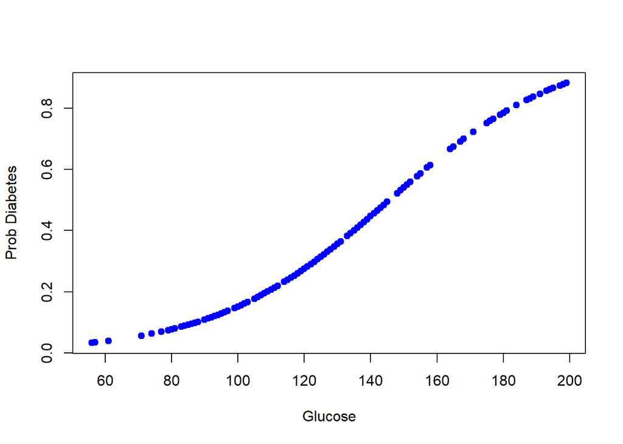

```r
plot(Pima.tr$glu, logmodel$fitted.values, pch = 19, col = "blue", xlab = "Glucose", ylab = "Prob Diabetes")
```

```r
confint(logmodel)
```

```
##                   2.5 %      97.5 %
## (Intercept) -7.24509356 -3.95278258
## glu          0.02611512  0.05084086
```

```r
exp(logmodel$coefficients)
```

```
## (Intercept)         glu
##  0.00407194  1.03850660
```

```r
exp(confint(logmodel))
```

```
##                    2.5 %    97.5 %
## (Intercept) 0.0007136674 0.0192012
## glu         1.0264591081 1.0521554
```

`mtcars` dataset

```r
data("mtcars")

logmodel <- glm(am ~ hp, data = mtcars, family = binomial)
summary(logmodel)
```

```
##
## Call:
## glm(formula = am ~ hp, family = binomial, data = mtcars)
##
## Coefficients:
##              Estimate Std. Error z value Pr(>|z|)
## (Intercept)  0.776614   0.915429   0.848    0.396
## hp          -0.008117   0.006074  -1.336    0.181
##
## (Dispersion parameter for binomial family taken to be 1)
##
##     Null deviance: 43.230  on 31  degrees of freedom
## Residual deviance: 41.228  on 30  degrees of freedom
## AIC: 45.228
##
## Number of Fisher Scoring iterations: 4
```

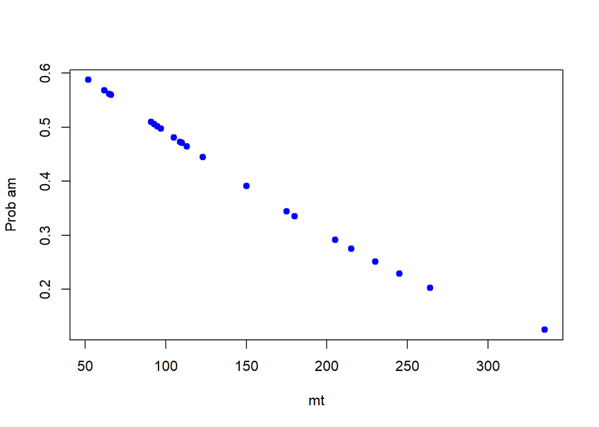

```r
plot(mtcars$hp, logmodel$fitted.values, pch = 19, col = "blue", xlab = "mt", ylab = "Prob am")
```

```r
confint(logmodel)
```

```
##                   2.5 %      97.5 %
## (Intercept) -0.97216559 2.685794052
## hp          -0.02140329 0.002963828
```

```r
exp(logmodel$coefficients)
```

```
## (Intercept)          hp
##   2.1740973   0.9919157
```

```r
exp(confint(logmodel))
```

```
##                 2.5 %    97.5 %
## (Intercept) 0.3782630 14.669845
## hp          0.9788241  1.002968
```

`iris` dataset

```r
data("iris")
iris$setosa <- ifelse(iris$Species == "setosa",1,0)
logmodel <- glm(setosa ~ Sepal.Length, data = iris, family = binomial)
summary(logmodel)
```

```
##
## Call:
## glm(formula = setosa ~ Sepal.Length, family = binomial, data = iris)
##
## Coefficients:
##              Estimate Std. Error z value Pr(>|z|)
## (Intercept)   27.8285     4.8276   5.765 8.19e-09 ***
## Sepal.Length  -5.1757     0.8934  -5.793 6.90e-09 ***
## ---
## Signif. codes:  0 '***' 0.001 '**' 0.01 '*' 0.05 '.' 0.1 ' ' 1
##
## (Dispersion parameter for binomial family taken to be 1)
##
##     Null deviance: 190.954  on 149  degrees of freedom
## Residual deviance:  71.836  on 148  degrees of freedom
## AIC: 75.836
##
## Number of Fisher Scoring iterations: 7
```

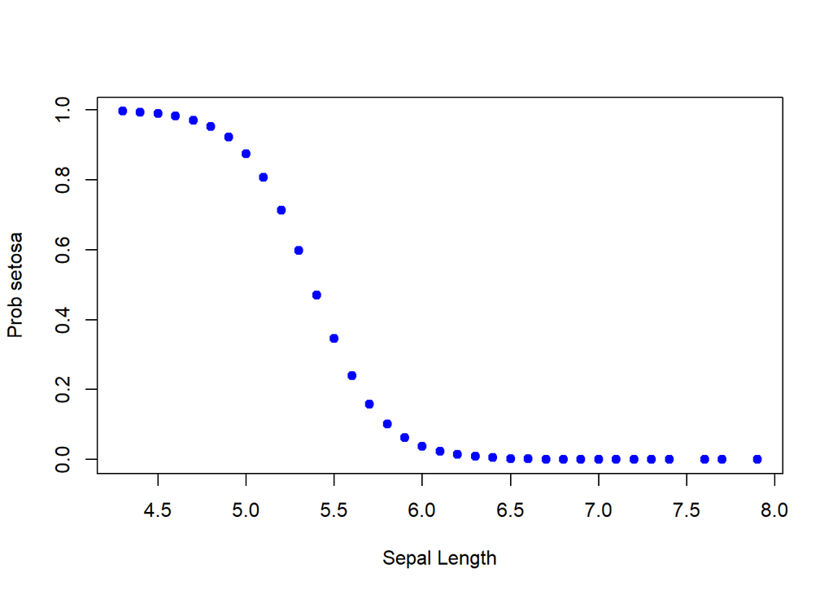

```r
plot(iris$Sepal.Length, logmodel$fitted.values, pch = 19, col = "blue", xlab = "Sepal Length", ylab = "Prob setosa")
```

```r
confint(logmodel)
```

```
##                  2.5 %   97.5 %
## (Intercept)  19.553051 38.69656
## Sepal.Length -7.187834 -3.64692
```

```r
exp(logmodel$coefficients)
```

```
##  (Intercept) Sepal.Length
## 1.218353e+12 5.652270e-03
```

```r
exp(confint(logmodel))
```

```
##                     2.5 %       97.5 %
## (Intercept)  3.103002e+08 6.392982e+16
## Sepal.Length 7.557243e-04 2.607130e-02
```

# Count data

The Poisson distribution is a discrete probability distribution used to model count data. It assumes that the data is unbounded which might not be the case for all count data examples. However, when the upper limit is unknown or is very large relative to the number of events we can model the counts as unbounded. If the upper bound is known, we can model the proportion or rate.

## Poisson regression Part I

Examples of counts:

- calls to a call center
- number of flu cases in an area
- number of cars that cross a bridge

examples of rates:

- percent of children passing a test
- percent of hits to a website from a country

The Poisson mass function is

$$X \sim Poisson\left(\lambda t\right) \Longleftrightarrow
\mathbb{P}\left(X = x\right) = \dfrac{\left(\lambda
t\right)^xe^{-\lambda t}}{x!}$$

- The mean and variance are $\lambda t$, and $E\left[X/t\right] = \lambda$ (the rate estimate).
- The Poisson tends to a normal as $\lambda t \rightarrow \infty$.

## Linear regression

Using linear regression for count data:

$$Y_i = \beta_0 + \beta_1X_i + \varepsilon_i$$

where:

- $\beta_0$ is the number of counts when $X = 0$
- $\beta_1$ is the increase in counts per unit increase of the predictor $X$ (for instance, the increase in visits of a website per unit day).

Now consider the model

$$log\left(Y_i\right) = \beta_0 + \beta_1x_i+\varepsilon_i$$
which is used since the quantity $e^{E\left[log\left(Y\right)\right]}$ estimates **the geometric mean** of $Y$:

$$e^{\frac{1}{n}\sum_{i=1}^{n}{log\left(y_i\right)}} =
\left(\prod_{i=1}^{n}{y_i}\right)^{1/n}$$

This is because when you take the natural logarithm of outcomes and fit a regression model, your exponentiated coefficients estimate things about geometric means:

- $e^{\beta_0}$ estimated geometric mean counts when $X = 0$.
- $e^{\beta_1}$ estimated relative increase or decrease in geometric mean counts per unit increase in $X$.

## Poisson Regression Part II

## Linear vs Poisson regression

Linear regression

$$Y_i = \beta_0 + \beta_1X_i + \varepsilon_i \Longrightarrow
E\left[Y_i \vert X_i,\beta_0,\beta_1\right] = \beta_0 + \beta_1X$$

Poisson/log-linear regression

$$log\left(E\left[Y_i \vert X_i,\beta_0,\beta_1\right]\right) =
\beta_0 + \beta_1X \Longrightarrow E\left[Y_i \vert
X_i,\beta_0,\beta_1\right] = e^{\beta_0 + \beta_1Xi}$$

Consider that the model is
$$E\left[Y_i \vert X_i, \beta_0,\beta_1\right] = e^{\beta_0 +
\beta_1X_i} = e^{\beta_0}e^{\beta_1X_i}$$

so that, a **unit increase** in $X_i$ leads to
$$E\left[Y_i \vert X_i, \beta_0,\beta_1\right] =
e^{\beta_0}e^{\beta_1X_i}\left[e^{\beta_1}\right]$$
which means that $E\left[Y_i \vert X_i, \beta_0,\beta_1\right]$ is multiplied by $e^{\beta_1}$

Let’s take a look at some examples:

1. Warpbreaks.

```r
data("warpbreaks")

modelo <- glm(breaks ~ wool, data = warpbreaks, family = poisson)
summary(modelo)
```

```
##
## Call:
## glm(formula = breaks ~ wool, family = poisson, data = warpbreaks)
##
## Coefficients:
##             Estimate Std. Error z value Pr(>|z|)
## (Intercept)  3.43518    0.03454  99.443  < 2e-16 ***
## woolB       -0.20599    0.05157  -3.994 6.49e-05 ***
## ---
## Signif. codes:  0 '***' 0.001 '**' 0.01 '*' 0.05 '.' 0.1 ' ' 1
##
## (Dispersion parameter for poisson family taken to be 1)
##
##     Null deviance: 297.37  on 53  degrees of freedom
## Residual deviance: 281.33  on 52  degrees of freedom
## AIC: 560
##
## Number of Fisher Scoring iterations: 4
```

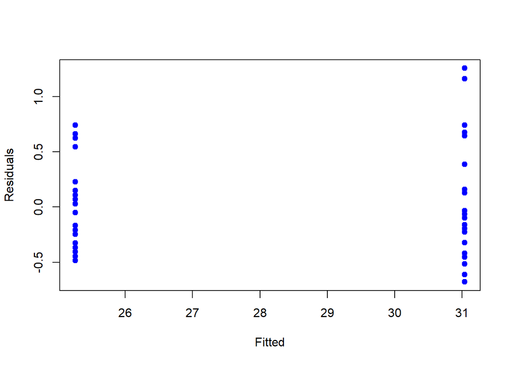

```r
### Check the mean-variance Poisson relationship

plot(modelo$fitted.values, modelo$residuals, pch = 19, col = "blue", ylab = "Residuals", xlab = "Fitted")
```

```r
### Quick diagnose
deviance(modelo) / df.residual(modelo)
```

```
## [1] 5.410259
```

2. Discoveries.

```r
data("discoveries")

modelo <- glm(discoveries ~ time(discoveries), data = discoveries, family = poisson)
summary(modelo)
```

```
##
## Call:
## glm(formula = discoveries ~ time(discoveries), family = poisson,
##     data = discoveries)
##
## Coefficients:
##                    Estimate Std. Error z value Pr(>|z|)
## (Intercept)       11.354807   3.775677   3.007  0.00264 **
## time(discoveries) -0.005360   0.001982  -2.705  0.00683 **
## ---
## Signif. codes:  0 '***' 0.001 '**' 0.01 '*' 0.05 '.' 0.1 ' ' 1
##
## (Dispersion parameter for poisson family taken to be 1)
##
##     Null deviance: 164.68  on 99  degrees of freedom
## Residual deviance: 157.32  on 98  degrees of freedom
## AIC: 430.32
##
## Number of Fisher Scoring iterations: 5
```

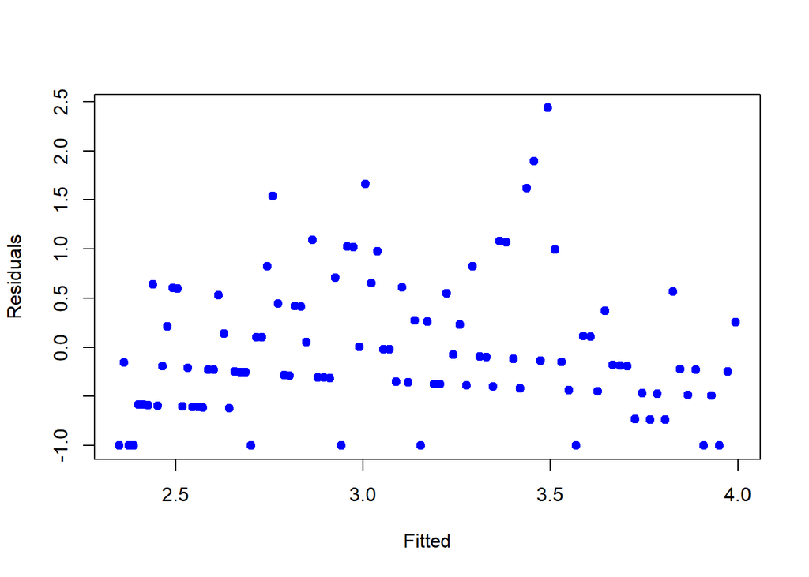

```r
### Check the mean-variance Poisson relationship

plot(modelo$fitted.values, modelo$residuals, pch = 19, col = "blue", ylab = "Residuals", xlab = "Fitted")
```

```r
### Quick diagnose
deviance(modelo) / df.residual(modelo)
```

```
## [1] 1.605264
```

3. Ships

```r
library("MASS")
data("ships")

modelo <- glm(incidents ~ type + year + offset(log(service+1)), data = ships, family = poisson)
summary(modelo)
```

```
##
## Call:
## glm(formula = incidents ~ type + year + offset(log(service +
##     1)), family = poisson, data = ships)
##
## Coefficients:
##             Estimate Std. Error z value Pr(>|z|)
## (Intercept) -9.47836    0.85064 -11.143  < 2e-16 ***
## typeB       -0.55786    0.17839  -3.127  0.00177 **
## typeC       -0.63167    0.32948  -1.917  0.05522 .
## typeD       -0.22250    0.28797  -0.773  0.43971
## typeE        0.38347    0.23486   1.633  0.10252
## year         0.05778    0.01185   4.876 1.08e-06 ***
## ---
## Signif. codes:  0 '***' 0.001 '**' 0.01 '*' 0.05 '.' 0.1 ' ' 1
##
## (Dispersion parameter for poisson family taken to be 1)
##
##     Null deviance: 146.292  on 39  degrees of freedom
## Residual deviance:  68.076  on 34  degrees of freedom
## AIC: 177.94
##
## Number of Fisher Scoring iterations: 5
```

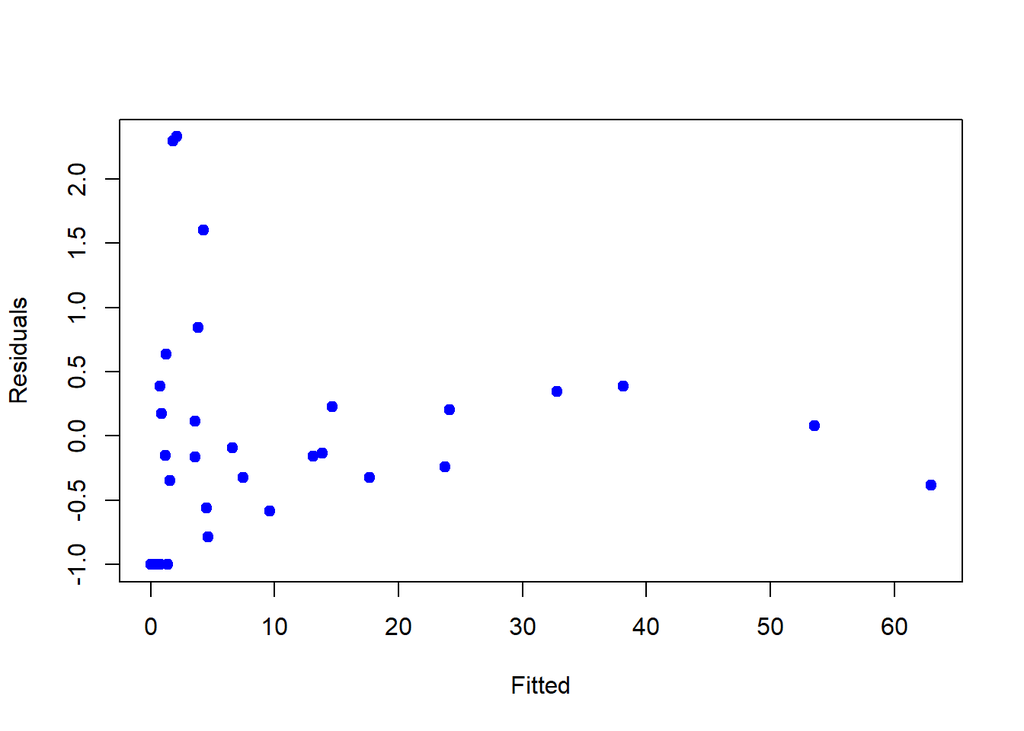

```r
### Check the mean-variance Poisson relationship

plot(modelo$fitted.values, modelo$residuals, pch = 19, col = "blue", ylab = "Residuals", xlab = "Fitted")
```

```r
### Quick diagnose
deviance(modelo) / df.residual(modelo)
```

```
## [1] 2.002223
```

# Hodgepodge

### Bonus material (Oh my God!)

How to fit functions using linear models? Up to this point, we only have fitted lines, planes, and polynomials for linear models. Consider a more general model

$$Y_i = f\left(X_i\right) + \varepsilon_i$$

Using the **scatterplot smoothing** we can fit such a model using linear models. The **regression splines** technique is a basic one for this end.

$$Y_i = \beta_0 + \beta_1X_i + \sum_{j=1}^{d}{I\left(x_i -
\xi_j\right)}\gamma_j + \varepsilon_i$$

where $\xi_1 \leq \dots \leq \xi_d$ are called the **knot points** and $I\left(\cdot\right)$ is the function defined as
$$I\left(x\right) = \left\{\begin{array}{rl}x & \text{if }x>0
\\ 0 & \text{if }x \leq 0\end{array}\right.$$

Let’s take a look at one example:

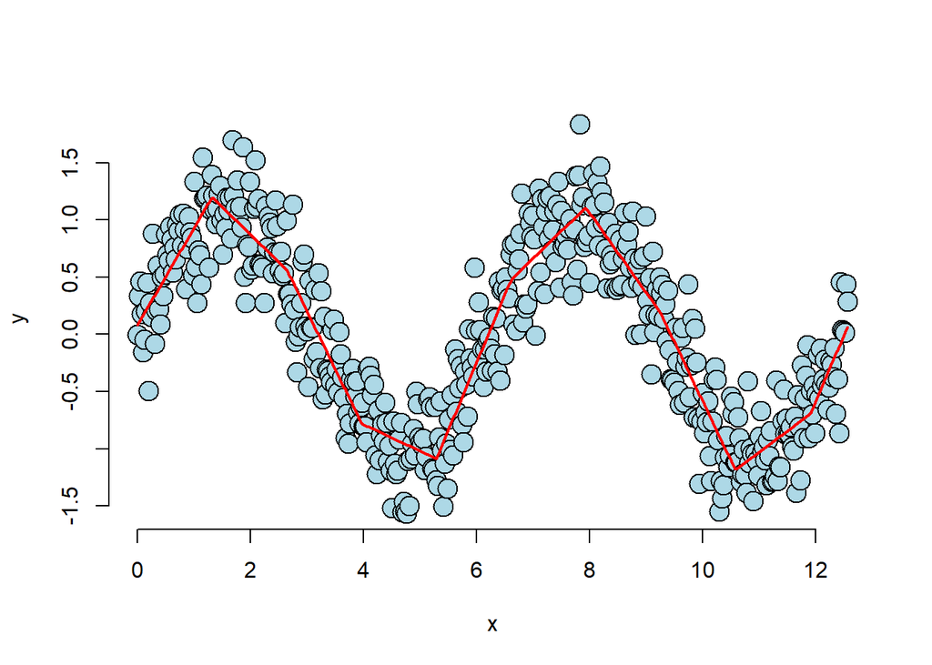

```r
n <- 500
x <- seq(0, 4 * pi, length = n)
y <- sin(x) + rnorm(n, sd = 0.3)
knots <- seq(0, 8 * pi, length = 20)
splineTerms <- sapply(knots, function(knot) (x > knot) * (x - knot))
xMat <- cbind(1,x,splineTerms)
yhat <- predict(lm(y ~ xMat - 1))
plot(x, y, frame = FALSE, pch = 21, bg = "lightblue", cex = 2)
lines(x, yhat, col = "red", lwd = 2)
```

HOWEVER, there is a big problem with this: the fitted function is non-differentiable at every knot point. In order to assess this problem, we can use squared terms instead to make the graph smooth (… and use cubic terms to make twice differentiable continuous at knot points, and so on):

$$Y_i = \beta_0 + \beta_1X_i + \beta_2X_i^2+ \sum_{j=1}^{d}{I\left(x_i
- \xi_j\right)^2}\gamma_j + \varepsilon_i$$

Let’s take a look at one example:

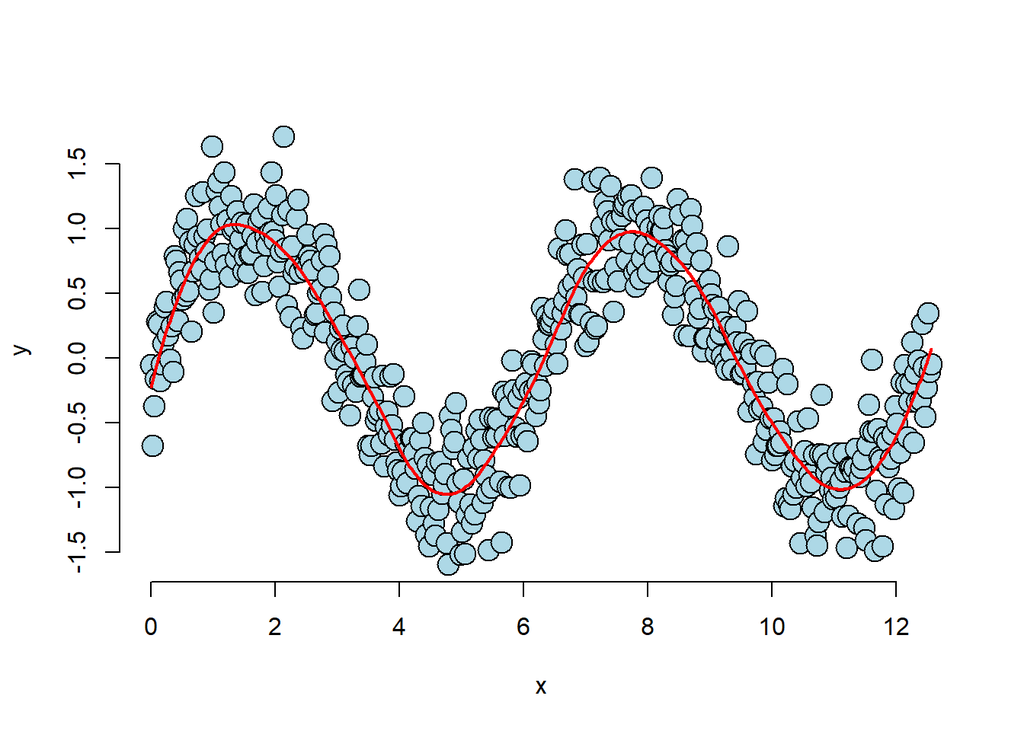

```r
n <- 500
x <- seq(0, 4 * pi, length = n)
y <- sin(x) + rnorm(n, sd = 0.3)
knots <- seq(0, 8 * pi, length = 20)
splineTerms <- sapply(knots, function(knot) (x > knot) * (x - knot)^2)
xMat <- cbind(1,x,x^2, splineTerms)
yhat <- predict(lm(y ~ xMat - 1))
plot(x, y, frame = FALSE, pch = 21, bg = "lightblue", cex = 2)
lines(x, yhat, col = "red", lwd = 2)
```

### Harmonics using linear models

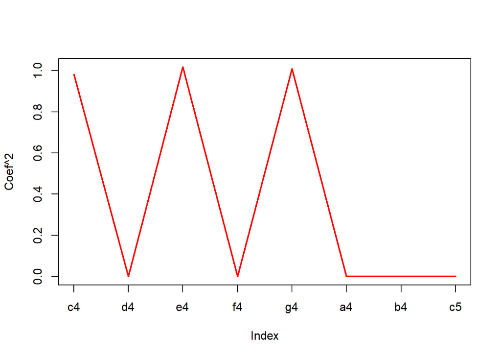

```r
notes4 <- c(261.63, 293.66, 329.63, 349.23, 392.00, 440.00, 493.88, 523.25)
t <- seq(0, 2, by = 0.001)
n <- length(t)
c4 <- sin(2 * pi * notes4[1] * t)
e4 <- sin(2 * pi * notes4[3] * t)
g4 <- sin(2 * pi * notes4[5] * t)
chord <- c4 + e4 + g4 + rnorm(n, mean = 0, sd = 0.3)
x <- sapply(notes4, function(freq) sin(2 * pi * freq * t))
fit <- lm( chord ~ x - 1)
Notes <- c("c4", "d4", "e4", "f4", "g4", "a4", "b4", "c5")
plot(fit$coefficients^2, ylab = "Coef^2", col = "red", type = "l", lwd = 2, xaxt = "n")
axis(1, at = seq(1,length(Notes), by = 1), labels = Notes)
```